# assignment

Ieva Gudelytė

2026-05-14

```r
suppressPackageStartupMessages({
  library(GenomicRanges)
  library(epiwraps)
  library(ggplot2)
  library(rGREAT) # Gene Ontology enrichment among genomic regions
})
```

# Downloading the data

The zip file contains bigwig files and peaks (bed) files for three TFs of the CREB family (all restricted to chr1; aligned against the hg38 genome)

```r
options(timeout = 6000)
download.file("https://ethz-ins.org/content/clustering_assignment.zip", "clustering_assignment.zip")
unzip("clustering_assignment.zip")
list.files()
```

# Preparing the regions and tracks

To get a clearer picture, we focus on high-confidence peaks from each factor to define the universe of regions

```r
tracks <- list.files(pattern="bw$")

# importing the peaks
peaks <- list.files(pattern="bed$")
peaks <- lapply(peaks, rtracklayer::import.bed)
# we'll focus on the high-quality peaks
peaks <- lapply(peaks, FUN=function(x) x[x$score>800])
# we combine all peak sets into one GRanges object, merge overlapping or directly adjacent peak intervals, and obtain a non-redundant set of genomic regions
regions <- reduce(unlist(GRangesList(peaks)))
```

# Investigating the relationships between the binding of Creb1, Creb3, and Creb3L1 proteins

We use clustering and visualization to illustrate these relationships

```r
ese <- signal2Matrix(tracks, regions, extend=2000)
```

```
## Reading Creb1.bw
```

```
## Reading Creb3.bw
```

```
## Reading Creb3L1.bw
```

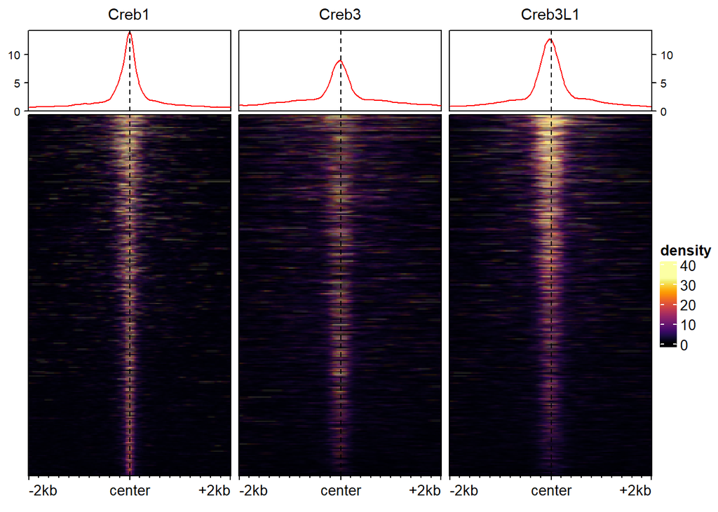

```r
plotEnrichedHeatmaps(ese)
```

Simply plotting the regions, the signals seem very similar… but are they? We take the first 1000 regions plotted above, make a heatmap of their signal profiles, cluster similar signal patterns together, and show the clustering tree.

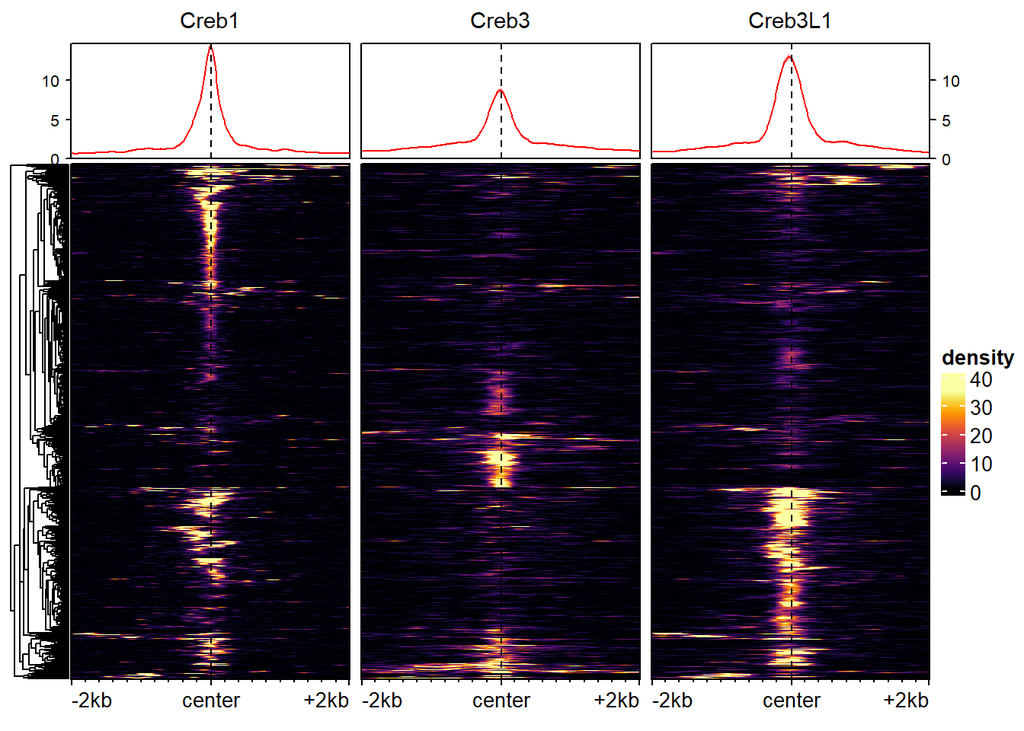

```r
ese2 <- ese[1:1000,]
plotEnrichedHeatmaps(ese2, cluster_rows = TRUE, show_row_dend=TRUE )
```

## Clustering

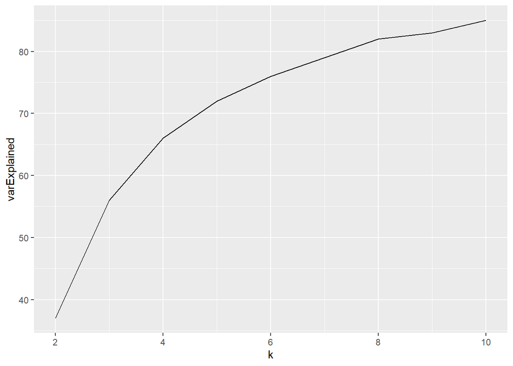

```r
# we set a seed for reproducibility
set.seed(123)

# trying different numbers of clusters:
cluster_test <- clusterSignalMatrices(ese, k=2:10)
ggplot(cluster_test$varExplained, aes(k, varExplained)) + geom_line()
```

```r
# we set a seed for reproducibility
set.seed(123)

# based on the plot above, 6 clusters seems like a good choice
cl <- clusterSignalMatrices(ese, k=6)
```

```
##   ~76% of the variance explained by clusters
```

```r
# cl is a cluster assignment vector
# counting how many regions were assigned to each cluster:
table(cl)
```

```
## cl
##   1   2   3   4   5   6
## 495 104 360 526 551 233
```

```r
# showing the cluster labels of the first 6 regions
head(cl)
```

```
## [1] 5 4 1 1 1 4
## Levels: 1 2 3 4 5 6
```

```r
# to make sure the cluster labels stay associated with the corresponding regions/rows even if we manipulate the object, put them inside the rowData of the object:
rowData(ese)$cluster <- cl
head(rowData(ese))
```

```
## DataFrame with 6 rows and 1 column
##                     cluster
##                    <factor>
## chr1:778487-779069        5
## chr1:904436-904985        4
## chr1:941785-942096        1
## chr1:943126-943501        1
## chr1:959088-959463        1
## chr1:961148-961904        4
```

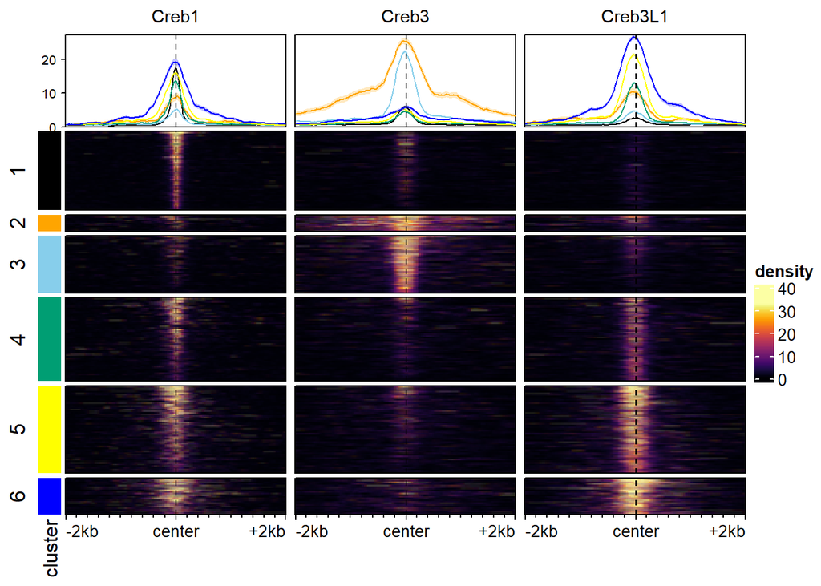

```r
# plotting the clusters
# adding colors:
mycolors <- c("1"="black", "2"="orange", "3"="skyblue", "4"="#009E73", "5"="yellow", "6"="blue")
plotEnrichedHeatmaps(ese, row_split=rowData(ese)$cluster, mean_color=mycolors)
```

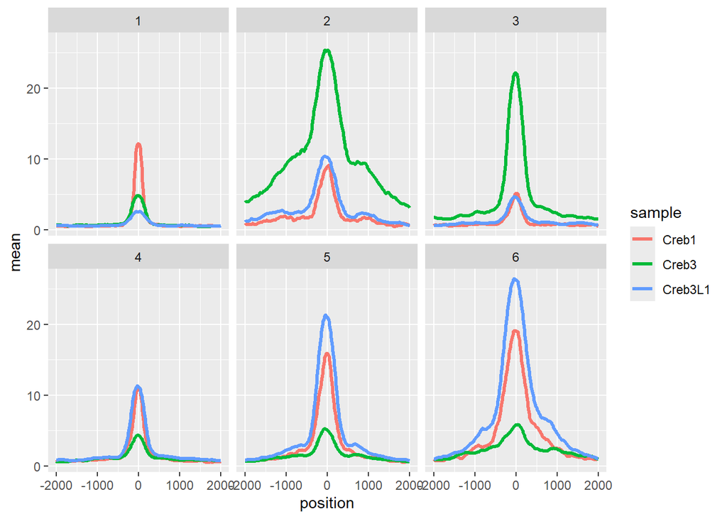

```r
# plotting just the averages:
d <- meltSignals(ese, splitBy=cl)
ggplot(d, aes(position, mean, colour=sample)) + geom_line(size=1.2) + facet_wrap(~split)
```

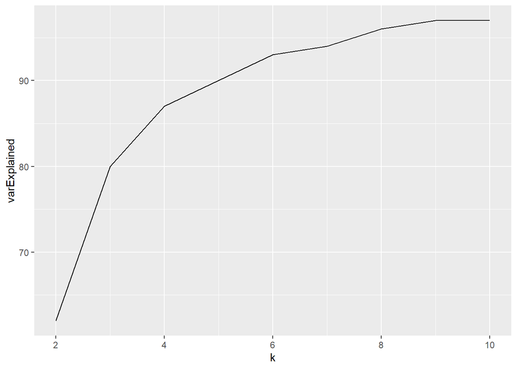

```r
# clustering using relative signal instead
# we set a seed for reproducibility
set.seed(123)

# trying different numbers of clusters:
cluster_test2 <- clusterSignalMatrices(ese, k=2:10, scaleRows = TRUE)
ggplot(cluster_test2$varExplained, aes(k, varExplained)) + geom_line()
```

```r
# we set a seed for reproducibility
set.seed(123)

# based on the plot above, 6 clusters seems like a good choice
cl_relative <- clusterSignalMatrices(ese, k=6, scaleRows = TRUE)
```

```
##   ~93% of the variance explained by clusters
```

```r
# to make sure the cluster labels stay associated with the corresponding regions/rows even if we manipulate the object, put them inside the rowData of the object:
rowData(ese)$cluster_relative <- cl_relative
head(rowData(ese))
```

```
## DataFrame with 6 rows and 2 columns
##                     cluster cluster_relative
##                    <factor>         <factor>
## chr1:778487-779069        5                5
## chr1:904436-904985        4                2
## chr1:941785-942096        1                1
## chr1:943126-943501        1                1
## chr1:959088-959463        1                1
## chr1:961148-961904        4                5
```

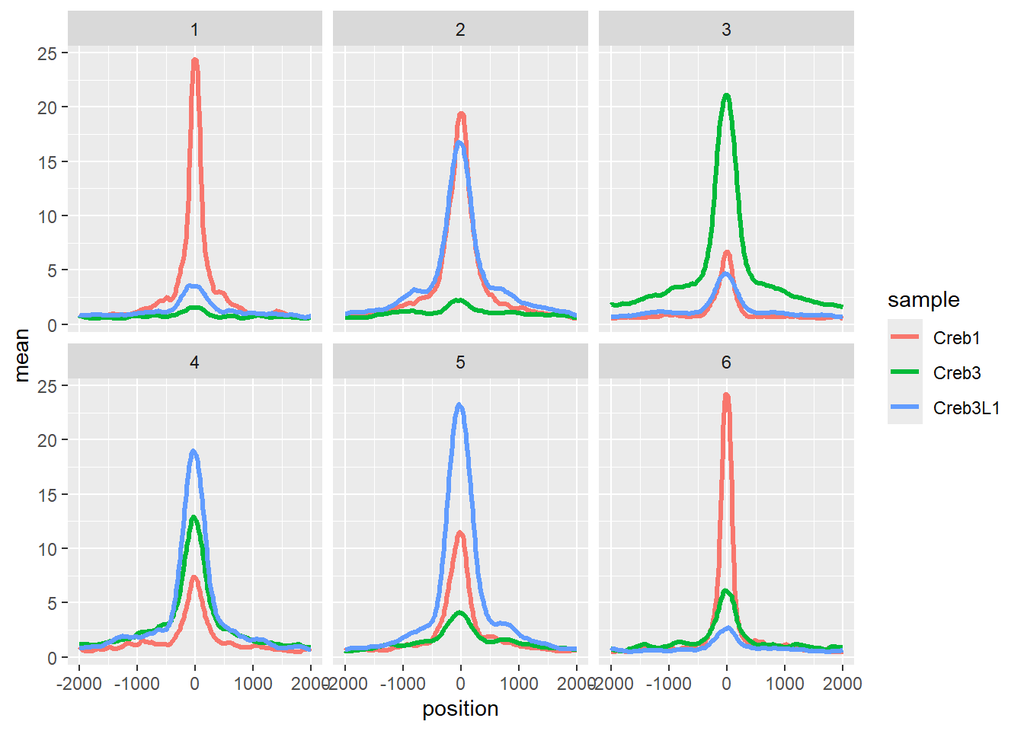

```r
d <- meltSignals(ese, splitBy=cl_relative)
ggplot(d, aes(position, mean, colour=sample)) + geom_line(size=1.2) + facet_wrap(~split)
```

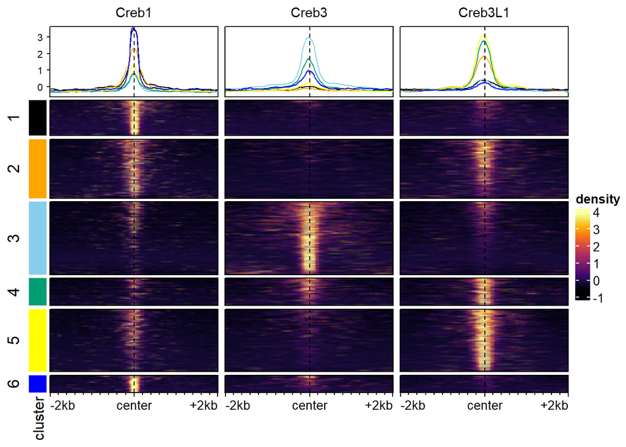

```r
mycolors <- c("1"="black", "2"="orange", "3"="skyblue", "4"="#009E73", "5"="yellow", "6"="blue")
plotEnrichedHeatmaps(ese, row_split=rowData(ese)$cluster_relative, scale_rows = "global", mean_color=mycolors)
```

# Enrichment analysis

Here we find what’s enriched in one cluster with respect to the others.

## Using unscaled signal

```r
# we first split the regions by cluster:
split_regions <- split(rowRanges(ese), rowData(ese)$cluster)
lengths(split_regions)
```

```
##   1   2   3   4   5   6
## 495 104 360 526 551 233
```

```r
# running GREAT-style enrichment analysis on cluster 3 regions
# we use the human hg38 genome annotation to link regions to nearby genes/TSSs
# gene_sets="GO:BP" specifies that we test enrichment for Gene Ontology Biological Process terms
res_3 <- great(split_regions[["3"]], gene_sets="GO:BP", tss_source="hg38",
             background=regions, cores=2)
```

```
## * TSS source: TxDb.
```

```
## * check whether TxDb package 'TxDb.Hsapiens.UCSC.hg38.knownGene' is installed.
```

```
## * gene ID type in the extended TSS is 'Entrez Gene ID'.
```

```
## * restrict chromosomes to 'chr1, chr2, chr3, chr4, chr5, chr6, chr7, chr8, chr9, chr10,
##     chr11, chr12, chr13, chr14, chr15, chr16, chr17, chr18, chr19, chr20, chr21, chr22, chrX,
##     chrY, chrM'.
```

```
## * 18193/35161 protein-coding genes left.
```

```
## * update seqinfo to the selected chromosomes.
```

```
## * TSS extension mode is 'basalPlusExt'.
```

```
## * construct the basal domains by extending 5000bp to upstream and 1000bp to downsteram of TSS.
```

```
## * calculate distances to neighbour regions.
```

```
## * extend to both sides until reaching the neighbour genes or to the maximal extension.
```

```
## * use GO:BP ontology with 15046 gene sets (source: org.Hs.eg.db).
```

```
## * check gene ID type in `gene_sets` and in `extended_tss`.
```

```
## * use self-defined background regions.
```

```
## * remove excluded regions from background.
```

```
## * overlap `gr` to background regions (based on midpoint).
```

```
## * in total 360 `gr`.
```

```
## * overlap extended TSS to background regions.
```

```
## * check which genes are in the gene sets.
```

```
## * only take gene sets with size >= 5.
```

```
## * in total 2479 gene sets.
```

```
## * overlap `gr` to every extended TSS.
```

```
## * perform binomial test for each biological term.
```

```r
bp_3 <- getEnrichmentTables(res_3)
bp_3 <- bp_3[order(bp_3$p_adjust), ]
head(bp_3, 15)
```

```
##            id                                  description genome_fraction
## 1  GO:0051716                cellular response to stimulus      0.57287343
## 2  GO:0050896                         response to stimulus      0.63875887
## 3  GO:0023052                                    signaling      0.50932561
## 4  GO:0007154                           cell communication      0.50691155
## 5  GO:0007165                          signal transduction      0.47545050
## 6  GO:0006950                           response to stress      0.37266704
## 7  GO:0048856             anatomical structure development      0.51818991
## 8  GO:0032943               mononuclear cell proliferation      0.03873879
## 9  GO:0070661                      leukocyte proliferation      0.03873879
## 10 GO:0042221                         response to chemical      0.32667451
## 11 GO:0006955                              immune response      0.17334060
## 12 GO:0001775                              cell activation      0.13217531
## 13 GO:0002684 positive regulation of immune system process      0.12620948
## 14 GO:0002682          regulation of immune system process      0.15856646
```

[output cut: 49 more lines]

```r
# same for cluster 2:
res_2 <- great(split_regions[["2"]], gene_sets="GO:BP", tss_source="hg38",
             background=regions, cores=2)
```

```
## * TSS source: TxDb.
```

```
## * extended_tss is already cached, directly use it.
```

```
## * use GO:BP ontology with 15046 gene sets (source: org.Hs.eg.db).
```

```
## * check gene ID type in `gene_sets` and in `extended_tss`.
```

```
## * use self-defined background regions.
```

```
## * remove excluded regions from background.
```

```
## * overlap `gr` to background regions (based on midpoint).
```

```
## * in total 104 `gr`.
```

```
## * overlap extended TSS to background regions.
```

```
## * check which genes are in the gene sets.
```

```
## * only take gene sets with size >= 5.
```

```
## * in total 2479 gene sets.
```

```
## * overlap `gr` to every extended TSS.
```

```
## * perform binomial test for each biological term.
```

```r
bp_2 <- getEnrichmentTables(res_2)
bp_2 <- bp_2[order(bp_2$p_adjust), ]
head(bp_2, 15)
```

```
##            id                                        description
## 1  GO:0030097                                        hemopoiesis
## 2  GO:1903131                   mononuclear cell differentiation
## 3  GO:0030183                             B cell differentiation
## 4  GO:0002521                          leukocyte differentiation
## 5  GO:0003151                        outflow tract morphogenesis
## 6  GO:0051649              establishment of localization in cell
## 7  GO:0072594 establishment of protein localization to organelle
## 8  GO:0060395                   SMAD protein signal transduction
## 9  GO:0030098                         lymphocyte differentiation
## 10 GO:0002274                       myeloid leukocyte activation
## 11 GO:0002376                              immune system process
## 12 GO:0051641                              cellular localization
## 13 GO:0030154                               cell differentiation
## 14 GO:0048869                     cellular developmental process
```

[output cut: 49 more lines]

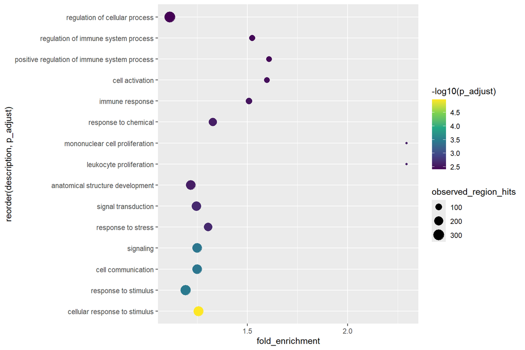

```r
# we plot the top Biological Processes for cluster 3:
ggplot(head(bp_3, 15), aes(fold_enrichment, reorder(description, p_adjust),
                        size=observed_region_hits, color=-log10(p_adjust))) +
  geom_point() + scale_color_viridis_c()
```

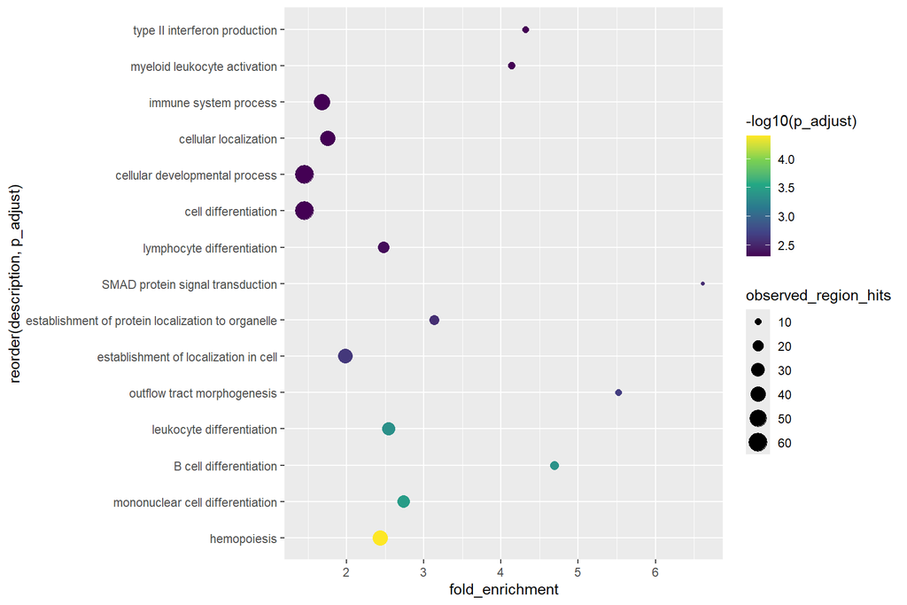

```r
# same for cluster 2:
ggplot(head(bp_2, 15), aes(fold_enrichment, reorder(description, p_adjust),
                        size=observed_region_hits, color=-log10(p_adjust))) +
  geom_point() + scale_color_viridis_c()
```

## Using scaled signal

```r
# we first split the regions by cluster:
split_regions_relative <- split(rowRanges(ese), rowData(ese)$cluster_relative)
lengths(split_regions_relative)
```

```
##   1   2   3   4   5   6
## 292 488 602 226 517 144
```

```r
# running GREAT-style enrichment analysis on cluster 3 regions
# we use the human hg38 genome annotation to link regions to nearby genes/TSSs
# gene_sets="GO:BP" specifies that we test enrichment for Gene Ontology Biological Process terms
res_relative <- great(split_regions_relative[["3"]], gene_sets="GO:BP", tss_source="hg38",
             background=regions, cores=2)
```

```
## * TSS source: TxDb.
```

```
## * extended_tss is already cached, directly use it.
```

```
## * use GO:BP ontology with 15046 gene sets (source: org.Hs.eg.db).
```

```
## * check gene ID type in `gene_sets` and in `extended_tss`.
```

```
## * use self-defined background regions.
```

```
## * remove excluded regions from background.
```

```
## * overlap `gr` to background regions (based on midpoint).
```

```
## * in total 602 `gr`.
```

```
## * overlap extended TSS to background regions.
```

```
## * check which genes are in the gene sets.
```

```
## * only take gene sets with size >= 5.
```

```
## * in total 2479 gene sets.
```

```
## * overlap `gr` to every extended TSS.
```

```
## * perform binomial test for each biological term.
```

```r
bp_relative <- getEnrichmentTables(res_relative)
bp_relative <- bp_relative[order(bp_relative$p_adjust), ]
head(bp_relative, 15)
```

```
##            id                      description genome_fraction
## 1  GO:0051716    cellular response to stimulus       0.5728734
## 2  GO:0002376            immune system process       0.2576506
## 3  GO:0007154               cell communication       0.5069115
## 4  GO:0001775                  cell activation       0.1321753
## 5  GO:0023052                        signaling       0.5093256
## 6  GO:0045321             leukocyte activation       0.1274130
## 7  GO:0050896             response to stimulus       0.6387589
## 8  GO:0006955                  immune response       0.1733406
## 9  GO:0050794   regulation of cellular process       0.7668011
## 10 GO:0009605    response to external stimulus       0.2323225
## 11 GO:0007165              signal transduction       0.4754505
## 12 GO:0032501 multicellular organismal process       0.5735694
## 13 GO:0006952                 defense response       0.1787465
## 14 GO:0048856 anatomical structure development       0.5181899
```

[output cut: 49 more lines]

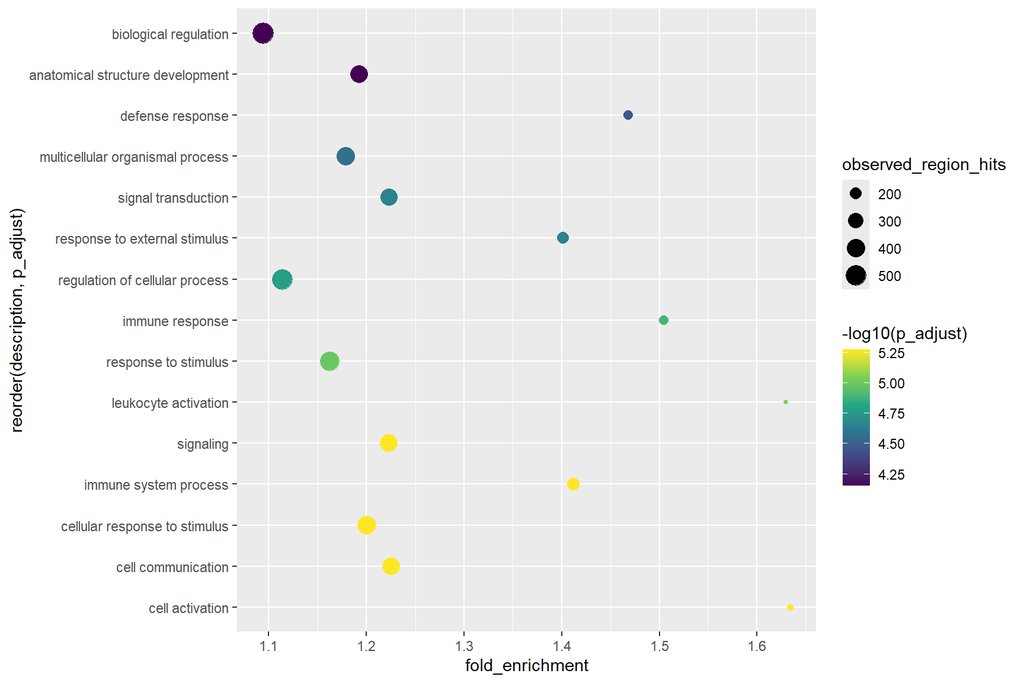

```r
# we plot the top Biological Processes:
ggplot(head(bp_relative,15), aes(fold_enrichment, reorder(description, p_adjust),
                        size=observed_region_hits, color=-log10(p_adjust))) +
  geom_point() + scale_color_viridis_c()
```

# Discussion

The signals produced by Creb1, Creb3, and Creb3L1 appear highly similar when visualized together. However, clustering reveals more complex relationships between these TFs. In the unscaled analysis, Creb1 and Creb3L1 frequently cluster together, suggesting that they share similar patterns of absolute signal strength across many regions, whereas Creb3 appears more distinct. When clustering is performed on scaled data, the association between Creb1 and Creb3L1 becomes weaker, which suggests that the previously observed correlations were driven partly by signal magnitude rather than purely by profile shape. GO enrichment analysis of clusters in which Creb3 is the dominant signal shows enrichment for several immune response-related biological processes. Although clusters derived from scaled and unscaled data cannot be directly compared, a strong Creb3 signal appears to be associated with immune-related processes in both analyses.